# UW Summer Institutes - Introduction to Metagenomic Data Analysis - Lab 8

# Setup

```r
library(phyloseq)
library(ggplot2)
library(ggthemes)
library(stringr)
library(tidyr)
library(dplyr)
```

1. Load the predicted metagenome data from for Nature 488, pp. 621-626: STAT.picrust.RData.

```r
load("../data/STAT.picrust.rdata")
```

2. Study the provided data: I. genes variable is a phyloseq object containing the metagenomic predictions (enzymes);

```r
str(genes)
```

```
Formal class 'phyloseq' [package "phyloseq"] with 5 slots
  ..@ otu_table:Formal class 'otu_table' [package "phyloseq"] with 2 slots
  .. .. ..@ .Data        : num [1:5061, 1:96] 2 603 1 1 20 50 53 5 1 1 ...
  .. .. .. ..- attr(*, "dimnames")=List of 2
  .. .. .. .. ..$ : chr [1:5061] "K01364" "K01360" "K02249" "K05841" ...
  .. .. .. .. ..$ : chr [1:96] "cecal.V5" "cecal.VP9" "fecal.C1" "fecal.VP10" ...
  .. .. ..@ taxa_are_rows: logi TRUE
  ..@ tax_table:Formal class 'taxonomyTable' [package "phyloseq"] with 1 slot
  .. .. ..@ .Data: chr [1:5061, 1:2] "K01364" "K01360" "K02249" "K05841" ...
  .. .. .. ..- attr(*, "dimnames")=List of 2
  .. .. .. .. ..$ : chr [1:5061] "K01364" "K01360" "K02249" "K05841" ...
  .. .. .. .. ..$ : chr [1:2] "ta1" "ta2"
  ..@ sam_data :'data.frame':   96 obs. of  5 variables:
Formal class 'sample_data' [package "phyloseq"] with 4 slots
  .. .. ..@ .Data    :List of 5
  .. .. .. ..$ : logi [1:96] NA NA NA NA NA NA ...
  .. .. .. ..$ : logi [1:96] NA NA NA NA NA NA ...
  .. .. .. ..$ : Factor w/ 5 levels "C","P","T","V",..: 4 5 1 5 3 5 5 3 5 5 ...
  .. .. .. ..$ : Factor w/ 2 levels "cecal","fecal": 1 1 2 2 1 1 1 2 1 1 ...
  .. .. .. ..$ : Factor w/ 1 level "missing_description": 1 1 1 1 1 1 1 1 1 1 ...
  .. .. ..@ names    : chr [1:5] "BarcodeSequence" "LinkerPrimerSequence" "Treatment" "Location" ...
  .. .. ..@ row.names: chr [1:96] "cecal.V5" "cecal.VP9" "fecal.C1" "fecal.VP10" ...
  .. .. ..@ .S3Class : chr "data.frame"
  ..@ phy_tree : NULL
  ..@ refseq   : NULL
```

```r
str(sample_data(genes))
```

```
'data.frame':   96 obs. of  5 variables:
Formal class 'sample_data' [package "phyloseq"] with 4 slots
  ..@ .Data    :List of 5
  .. ..$ : logi  NA NA NA NA NA NA ...
  .. ..$ : logi  NA NA NA NA NA NA ...
  .. ..$ : Factor w/ 5 levels "C","P","T","V",..: 4 5 1 5 3 5 5 3 5 5 ...
  .. ..$ : Factor w/ 2 levels "cecal","fecal": 1 1 2 2 1 1 1 2 1 1 ...
  .. ..$ : Factor w/ 1 level "missing_description": 1 1 1 1 1 1 1 1 1 1 ...
  ..@ names    : chr  "BarcodeSequence" "LinkerPrimerSequence" "Treatment" "Location" ...
  ..@ row.names: chr  "cecal.V5" "cecal.VP9" "fecal.C1" "fecal.VP10" ...
  ..@ .S3Class : chr "data.frame"
```

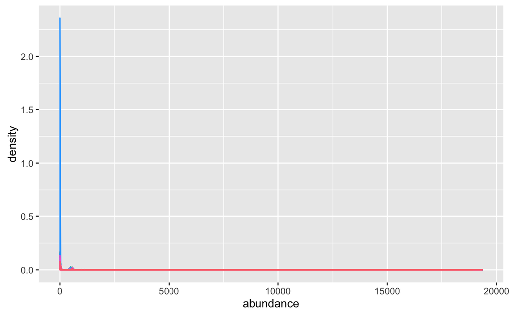

```r
otu_table(genes) %>%
    as.data.frame() %>%
    gather(sample, abundance) %>%
    ggplot(aes(x = abundance)) +
    geom_density(aes(colour = sample)) +
    guides(colour = FALSE)
```

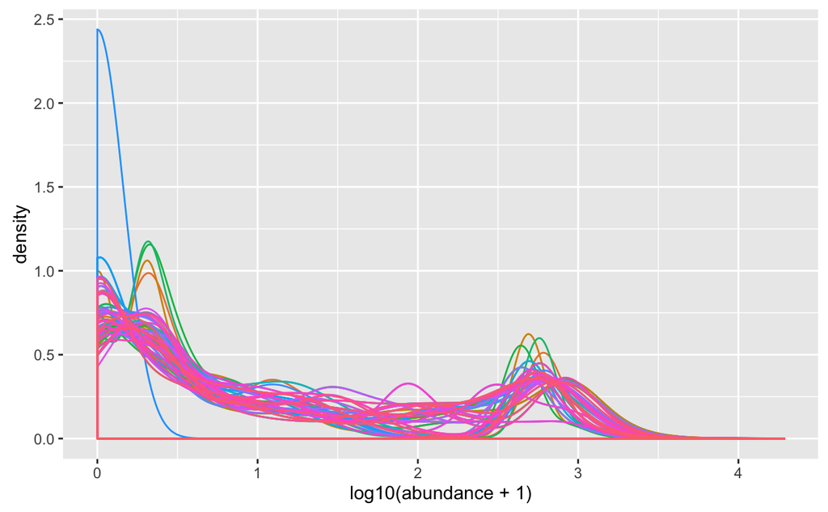

```r
otu_table(genes) %>%
    as.data.frame() %>%
    gather(sample, abundance) %>%
    ggplot(aes(x = log10(abundance + 1))) +
    geom_density(aes(colour = sample)) +
    guides(colour = FALSE)
```

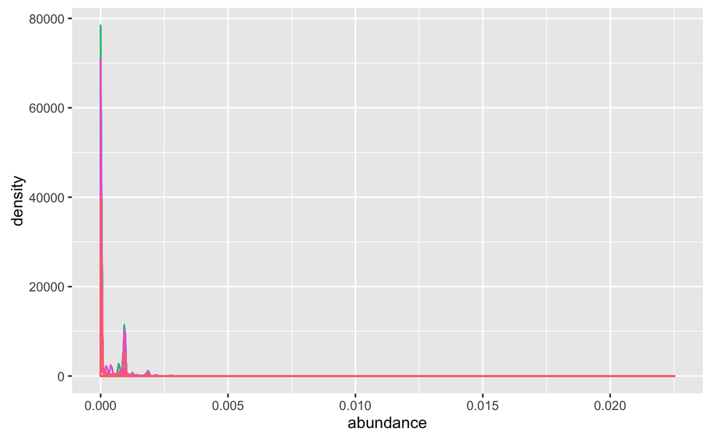

```r
transform_sample_counts(genes, function(x) x / sum(x)) %>%
    otu_table() %>%
    as.data.frame() %>%
    gather(sample, abundance) %>%
    ggplot(aes(x = abundance)) +
    geom_density(aes(colour = sample)) +
    guides(colour = FALSE)
```

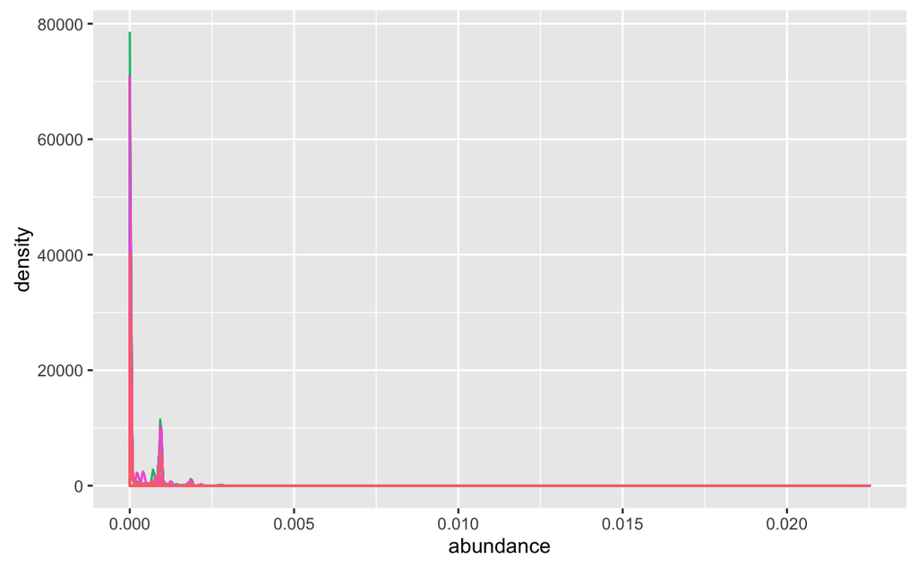

```r
prune_taxa(taxa_sums(genes) > 0, genes) %>%
    transform_sample_counts(function(x) x / sum(x)) %>%
    otu_table() %>%
    as.data.frame() %>%
    gather(sample, abundance) %>%
    ggplot(aes(x = abundance)) +
    geom_density(aes(colour = sample)) +
    guides(colour = FALSE)
```

2. pathways variable identifies biological pathways in which the metagenomic predictions participate.

```r
str(pathways)
```

```
'data.frame':   10213 obs. of  4 variables:
 $ KO    : chr  "K01365" "K01365" "K01365" "K01365" ...
 $ Level1: chr  "Human Diseases" "Metabolism" "Organismal Systems" "Cellular Processes" ...
 $ Level2: chr  "Immune System Diseases" "Enzyme Families" "Immune System" "Transport and Catabolism" ...
 $ Level3: chr  "Rheumatoid arthritis" "Peptidases" "Antigen processing and presentation" "Phagosome" ...
```

```r
head(pathways)
```

```
      KO                         Level1                           Level2
1 K01365                 Human Diseases           Immune System Diseases
2 K01365                     Metabolism                  Enzyme Families
3 K01365             Organismal Systems                    Immune System
4 K01365             Cellular Processes         Transport and Catabolism
5 K01365 Genetic Information Processing Folding, Sorting and Degradation
6 K01365             Cellular Processes         Transport and Catabolism
                               Level3
1                Rheumatoid arthritis
2                          Peptidases
3 Antigen processing and presentation
4                           Phagosome
5    Chaperones and folding catalysts
6                            Lysosome
```

3. Use appropriate normalization technique to normalize the data.

```r
genes_norm <- prune_taxa(taxa_sums(genes) > 0, genes) %>%
    transform_sample_counts(function(x) x / sum(x))
str(genes_norm)
```

```
Formal class 'phyloseq' [package "phyloseq"] with 5 slots
  ..@ otu_table:Formal class 'otu_table' [package "phyloseq"] with 2 slots
  .. .. ..@ .Data        : num [1:5061, 1:96] 3.39e-06 1.02e-03 1.70e-06 1.70e-06 3.39e-05 ...
  .. .. .. ..- attr(*, "dimnames")=List of 2
  .. .. .. .. ..$ : chr [1:5061] "K01364" "K01360" "K02249" "K05841" ...
  .. .. .. .. ..$ : chr [1:96] "cecal.V5" "cecal.VP9" "fecal.C1" "fecal.VP10" ...
  .. .. ..@ taxa_are_rows: logi TRUE
  ..@ tax_table:Formal class 'taxonomyTable' [package "phyloseq"] with 1 slot
  .. .. ..@ .Data: chr [1:5061, 1:2] "K01364" "K01360" "K02249" "K05841" ...
  .. .. .. ..- attr(*, "dimnames")=List of 2
  .. .. .. .. ..$ : chr [1:5061] "K01364" "K01360" "K02249" "K05841" ...
  .. .. .. .. ..$ : chr [1:2] "ta1" "ta2"
  ..@ sam_data :'data.frame':   96 obs. of  5 variables:
Formal class 'sample_data' [package "phyloseq"] with 4 slots
  .. .. ..@ .Data    :List of 5
  .. .. .. ..$ : logi [1:96] NA NA NA NA NA NA ...
  .. .. .. ..$ : logi [1:96] NA NA NA NA NA NA ...
  .. .. .. ..$ : Factor w/ 5 levels "C","P","T","V",..: 4 5 1 5 3 5 5 3 5 5 ...
  .. .. .. ..$ : Factor w/ 2 levels "cecal","fecal": 1 1 2 2 1 1 1 2 1 1 ...
  .. .. .. ..$ : Factor w/ 1 level "missing_description": 1 1 1 1 1 1 1 1 1 1 ...
  .. .. ..@ names    : chr [1:5] "BarcodeSequence" "LinkerPrimerSequence" "Treatment" "Location" ...
  .. .. ..@ row.names: chr [1:96] "cecal.V5" "cecal.VP9" "fecal.C1" "fecal.VP10" ...
  .. .. ..@ .S3Class : chr "data.frame"
  ..@ phy_tree : NULL
  ..@ refseq   : NULL
```

4. Perform principal components analysis ordination of the data, plot the results.

```r
genes_pcoa <- ordinate(genes_norm, method = "PCoA", distance = "jsd")
```

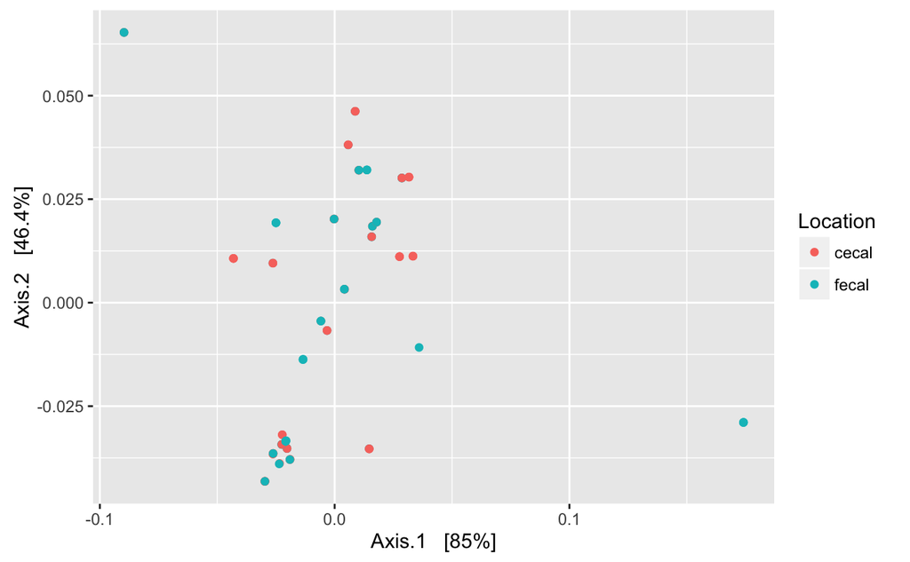

```r
plot_ordination(genes_norm, genes_pcoa, color = "Location")
```

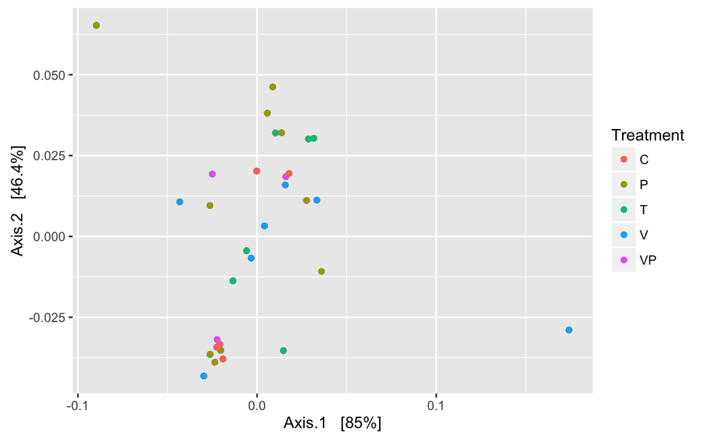

```r
plot_ordination(genes_norm, genes_pcoa, color = "Treatment")
```

5. Are these data multivariately associated with Location and/or Treatment? Which distance do you use for this analysis?

```r
library(vegan)
library(ade4)
genes_jsd <- phyloseq::distance(genes_norm, "jsd")
?distance
jsd_pco = dudi.pco(cailliez(genes_jsd), scannf=F, nf=2)
```

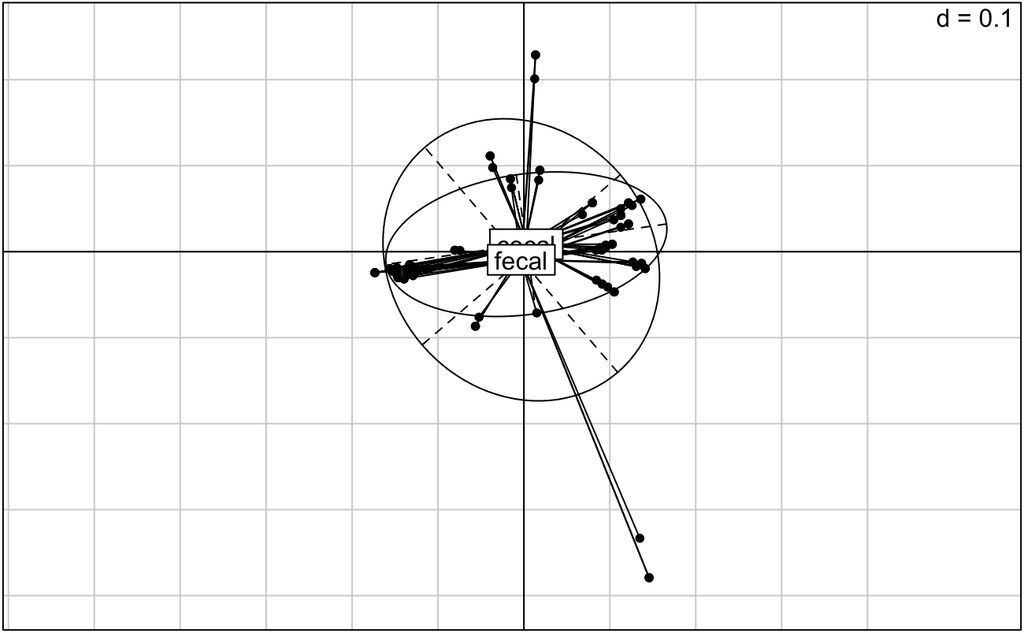

```r
s.class(jsd_pco$li, sample_data(genes_norm)$Location)
```

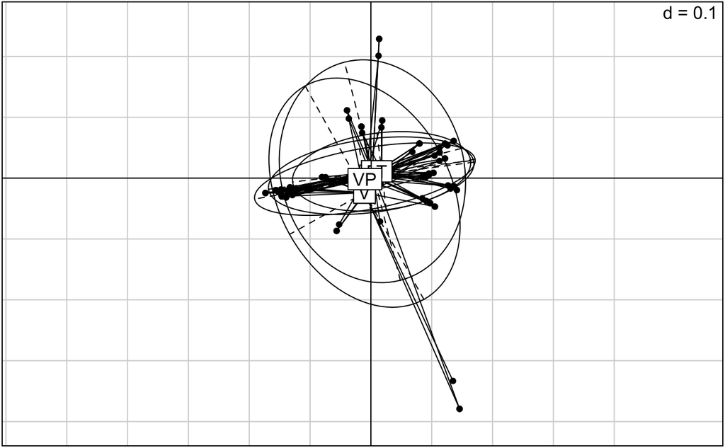

```r
s.class(jsd_pco$li, sample_data(genes_norm)$Treatment)
```

6. Perform univariate analysis of the metagenomic predictions with respect to the Location variable. What test do you use? Do not forget about adjustment for multiple comparisons! Report any positive results.
7. Fisher exact test, fisher.test, can be used to determine if a biological pathway is enriched for significant enzymes. Use this test on Level 1 pathways. Report any enriched pathways and perform the analysis at Level 2 for them.
8. Perform the same analysis with respect to Treatment variable within the cecal samples. Note: use coefficient of variation cv = s.d./mean to filter out enzymes that do not vary much. Keep only enzymes with cv>1.

What statistical test do you use to compare enzyme abundance in control and antibiotic groups?

Bonus: Load whole metagenome sequence data from Human Microbiome Project and experiment with these data (http://hmpdacc.org/HMMRC/).